# McDonald's

```python
import numpy as np
import pandas as pd
import matplotlib.pyplot as plt
%matplotlib inline
import seaborn as sns
from warnings import filterwarnings
filterwarnings("ignore")
```

```python
df = pd.read_csv('Mcdonald .csv')
df.head()
```

|  | Category | Item | Serving Size | Calories | Calories from Fat | Total Fat | Total Fat (% Daily Value) | Saturated Fat | Saturated Fat (% Daily Value) | Trans Fat | ... | Carbohydrates | Carbohydrates (% Daily Value) | Dietary Fiber | Dietary Fiber (% Daily Value) | Sugars | Protein | Vitamin A (% Daily Value) | Vitamin C (% Daily Value) | Calcium (% Daily Value) | Iron (% Daily Value) |
| --- | --- | --- | --- | --- | --- | --- | --- | --- | --- | --- | --- | --- | --- | --- | --- | --- | --- | --- | --- | --- | --- |
| 0 | Breakfast | Egg McMuffin | 4.8 oz (136 g) | 300 | 120 | 13.0 | 20 | 5.0 | 25 | 0.0 | ... | 31 | 10 | 4 | 17 | 3 | 17 | 10 | 0 | 25 | 15 |
| 1 | Breakfast | Egg White Delight | 4.8 oz (135 g) | 250 | 70 | 8.0 | 12 | 3.0 | 15 | 0.0 | ... | 30 | 10 | 4 | 17 | 3 | 18 | 6 | 0 | 25 | 8 |
| 2 | Breakfast | Sausage McMuffin | 3.9 oz (111 g) | 370 | 200 | 23.0 | 35 | 8.0 | 42 | 0.0 | ... | 29 | 10 | 4 | 17 | 2 | 14 | 8 | 0 | 25 | 10 |
| 3 | Breakfast | Sausage McMuffin with Egg | 5.7 oz (161 g) | 450 | 250 | 28.0 | 43 | 10.0 | 52 | 0.0 | ... | 30 | 10 | 4 | 17 | 2 | 21 | 15 | 0 | 30 | 15 |
| 4 | Breakfast | Sausage McMuffin with Egg Whites | 5.7 oz (161 g) | 400 | 210 | 23.0 | 35 | 8.0 | 42 | 0.0 | ... | 30 | 10 | 4 | 17 | 2 | 21 | 6 | 0 | 25 | 10 |

5 rows × 24 columns

```python
df.info()
```

```
<class 'pandas.core.frame.DataFrame'>
RangeIndex: 260 entries, 0 to 259
Data columns (total 24 columns):
 #   Column                         Non-Null Count  Dtype
---  ------                         --------------  -----
 0   Category                       260 non-null    object
 1   Item                           260 non-null    object
 2   Serving Size                   260 non-null    object
 3   Calories                       260 non-null    int64
 4   Calories from Fat              260 non-null    int64
 5   Total Fat                      260 non-null    float64
 6   Total Fat (% Daily Value)      260 non-null    int64
 7   Saturated Fat                  260 non-null    float64
 8   Saturated Fat (% Daily Value)  260 non-null    int64
 9   Trans Fat                      260 non-null    float64
```

[output cut: 16 more lines]

**_Observation_**: *Only three Variables are of object dtype. Rest all the variables are numeric, either of float or of int dtype.* *There are no NULL values present in the dataframe. So the dataframe is a clean dataset.* *Total rows are 260 and total columns are 24.*

```python
df.describe().T           #Statistics summary table of the dataframe
```

|  | count | mean | std | min | 25% | 50% | 75% | max |
| --- | --- | --- | --- | --- | --- | --- | --- | --- |
| Calories | 260.0 | 368.269231 | 240.269886 | 0.0 | 210.000 | 340.0 | 500.00 | 1880.0 |
| Calories from Fat | 260.0 | 127.096154 | 127.875914 | 0.0 | 20.000 | 100.0 | 200.00 | 1060.0 |
| Total Fat | 260.0 | 14.165385 | 14.205998 | 0.0 | 2.375 | 11.0 | 22.25 | 118.0 |
| Total Fat (% Daily Value) | 260.0 | 21.815385 | 21.885199 | 0.0 | 3.750 | 17.0 | 35.00 | 182.0 |
| Saturated Fat | 260.0 | 6.007692 | 5.321873 | 0.0 | 1.000 | 5.0 | 10.00 | 20.0 |
| Saturated Fat (% Daily Value) | 260.0 | 29.965385 | 26.639209 | 0.0 | 4.750 | 24.0 | 48.00 | 102.0 |
| Trans Fat | 260.0 | 0.203846 | 0.429133 | 0.0 | 0.000 | 0.0 | 0.00 | 2.5 |
| Cholesterol | 260.0 | 54.942308 | 87.269257 | 0.0 | 5.000 | 35.0 | 65.00 | 575.0 |
| Cholesterol (% Daily Value) | 260.0 | 18.392308 | 29.091653 | 0.0 | 2.000 | 11.0 | 21.25 | 192.0 |
| Sodium | 260.0 | 495.750000 | 577.026323 | 0.0 | 107.500 | 190.0 | 865.00 | 3600.0 |
| Sodium (% Daily Value) | 260.0 | 20.676923 | 24.034954 | 0.0 | 4.750 | 8.0 | 36.25 | 150.0 |
| Carbohydrates | 260.0 | 47.346154 | 28.252232 | 0.0 | 30.000 | 44.0 | 60.00 | 141.0 |
| Carbohydrates (% Daily Value) | 260.0 | 15.780769 | 9.419544 | 0.0 | 10.000 | 15.0 | 20.00 | 47.0 |
| Dietary Fiber | 260.0 | 1.630769 | 1.567717 | 0.0 | 0.000 | 1.0 | 3.00 | 7.0 |
| Dietary Fiber (% Daily Value) | 260.0 | 6.530769 | 6.307057 | 0.0 | 0.000 | 5.0 | 10.00 | 28.0 |
| Sugars | 260.0 | 29.423077 | 28.679797 | 0.0 | 5.750 | 17.5 | 48.00 | 128.0 |
| Protein | 260.0 | 13.338462 | 11.426146 | 0.0 | 4.000 | 12.0 | 19.00 | 87.0 |
| Vitamin A (% Daily Value) | 260.0 | 13.426923 | 24.366381 | 0.0 | 2.000 | 8.0 | 15.00 | 170.0 |
| Vitamin C (% Daily Value) | 260.0 | 8.534615 | 26.345542 | 0.0 | 0.000 | 0.0 | 4.00 | 240.0 |
| Calcium (% Daily Value) | 260.0 | 20.973077 | 17.019953 | 0.0 | 6.000 | 20.0 | 30.00 | 70.0 |
| Iron (% Daily Value) | 260.0 | 7.734615 | 8.723263 | 0.0 | 0.000 | 4.0 | 15.00 | 40.0 |

## 1. Plot graphically which food categories have the highest and lowest varieties.

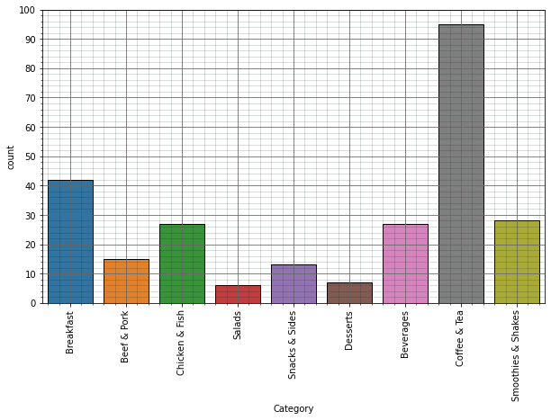

```python
sns.countplot("Category",data=df,edgecolor='black');
fig = plt.gcf()
fig.set_figwidth(10)
fig.set_figheight(6)
plt.xticks(rotation = 90);
plt.yticks([0,10,20,30,40,50,60,70,80,90,100])
plt.grid(b=True, which='major', color='#666666', linestyle='-')
plt.minorticks_on()
plt.grid(b=True, which='minor', color='#011f1f', linestyle='-', alpha=0.2)
```

**Observation: 'Salads' category has the lowest number of varieties and 'Coffee and Tea' category has the highest number of varieties.**

## 2. Which all variables have an outlier?

**1) One way to look at the outliers for every category.**

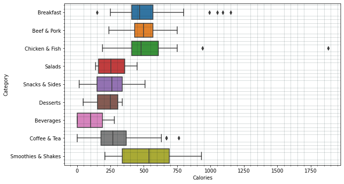

```python
sns.boxplot('Calories','Category',data=df);
fig = plt.gcf()
fig.set_figwidth(10)
fig.set_figheight(6)
plt.minorticks_on()
plt.grid(b=True, which='minor', color='#011f1f', linestyle='-', alpha=0.2)
```

_**Observation**_: **"Chicken and Fish" category has the farthest outlier of a value of 1880, in case of "Calories".**

**2) Another way to look at outliers is by observing boxplots of all columns present in the dataframe in one plot.**

**- Excluded those variables/Columns with 'very low values' when compared to the values of other Variables/columns like "Cholestrol" and "Total fat"**

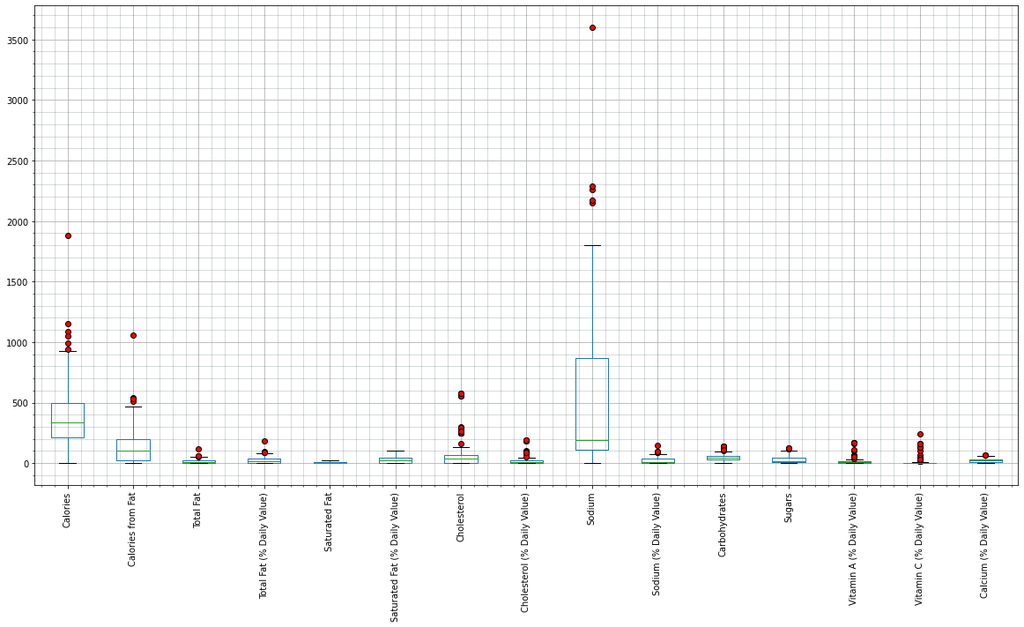

```python
boxplot = df.boxplot(
    column=['Calories', 'Calories from Fat','Total Fat',
            'Total Fat (% Daily Value)','Saturated Fat','Saturated Fat (% Daily Value)',
           'Cholesterol','Cholesterol (% Daily Value)','Sodium','Sodium (% Daily Value)',
           'Carbohydrates','Sugars','Vitamin A (% Daily Value)','Vitamin C (% Daily Value)',
           'Calcium (% Daily Value)'],figsize=(20,10),
    flierprops=dict(markerfacecolor='r', marker='o'))
plt.xticks(rotation = 90);
plt.minorticks_on()
plt.grid(b=True, which='minor', color='#011f1f', linestyle='-', alpha=0.2)
plt.show()
```

_**Observation**_: **All Variables in the plot, except "Saturated fat" and "Saturated Fat(%Daily Value)", have outliers.**

**Variables 'Calories', 'Calories from Fat', 'Cholestrol' and 'Sodium' have outliers very far away from their maximum values of boxplots.**

_**3) There is a way to know the outlier values that is present in a Variable/column by using boxplot_stats with the dataframe. It gives out a dictionary that lists the box-and-whisker values as It is shown below. It can be observed that it gave out an array of fliers/outlier values that can be extracted seperately.**_

```python
from matplotlib.cbook import boxplot_stats
boxplot_stats(df['Calories'].values)
```

```
[{'mean': 368.2692307692308,
  'iqr': 290.0,
  'cilo': 311.7634926707667,
  'cihi': 368.2365073292333,
  'whishi': 930,
  'whislo': 0,
  'fliers': array([1090, 1150,  990, 1050,  940, 1880]),
  'q1': 210.0,
  'med': 340.0,
  'q3': 500.0}]
```

```python
boxplot_stats(df['Calories']).pop(0)['fliers']
#extracts an array of outliers from boxplot_stats of variable 'Calories'
```

```
array([1090, 1150,  990, 1050,  940, 1880])
```

## 3. Which variables have the highest correlation? Plot them and find out the value?

```python
corr=df.corr()
filteredDf = corr[((corr >= .5) | (corr <= -.5)) & (corr !=1.000)]
#filtered correlation values between -0.5 and 0.5 and, correlation values of 1.0
filteredDf.head()
```

|  | Calories | Calories from Fat | Total Fat | Total Fat (% Daily Value) | Saturated Fat | Saturated Fat (% Daily Value) | Trans Fat | Cholesterol | Cholesterol (% Daily Value) | Sodium | ... | Carbohydrates | Carbohydrates (% Daily Value) | Dietary Fiber | Dietary Fiber (% Daily Value) | Sugars | Protein | Vitamin A (% Daily Value) | Vitamin C (% Daily Value) | Calcium (% Daily Value) | Iron (% Daily Value) |
| --- | --- | --- | --- | --- | --- | --- | --- | --- | --- | --- | --- | --- | --- | --- | --- | --- | --- | --- | --- | --- | --- |
| Calories | NaN | 0.904588 | 0.904409 | 0.904123 | 0.845564 | 0.847631 | 0.522441 | 0.596399 | 0.595208 | 0.712309 | ... | 0.781539 | 0.781242 | 0.538894 | 0.540014 | NaN | 0.787847 | NaN | NaN | NaN | 0.643552 |
| Calories from Fat | 0.904588 | NaN | 0.999663 | 0.999725 | 0.847008 | 0.849592 | NaN | 0.682161 | 0.681607 | 0.846624 | ... | NaN | NaN | 0.581274 | 0.575621 | NaN | 0.807913 | NaN | NaN | NaN | 0.735894 |
| Total Fat | 0.904409 | 0.999663 | NaN | 0.999765 | 0.846707 | 0.849293 | NaN | 0.680547 | 0.680000 | 0.846158 | ... | NaN | NaN | 0.580837 | 0.575206 | NaN | 0.807773 | NaN | NaN | NaN | 0.734685 |
| Total Fat (% Daily Value) | 0.904123 | 0.999725 | 0.999765 | NaN | 0.847379 | 0.849973 | NaN | 0.680940 | 0.680378 | 0.846728 | ... | NaN | NaN | 0.580592 | 0.575033 | NaN | 0.807922 | NaN | NaN | NaN | 0.735478 |
| Saturated Fat | 0.845564 | 0.847008 | 0.846707 | 0.847379 | NaN | 0.999279 | 0.620611 | 0.631210 | 0.630334 | 0.584075 | ... | 0.591261 | 0.591743 | NaN | NaN | NaN | 0.603028 | NaN | NaN | NaN | 0.578062 |

5 rows × 21 columns

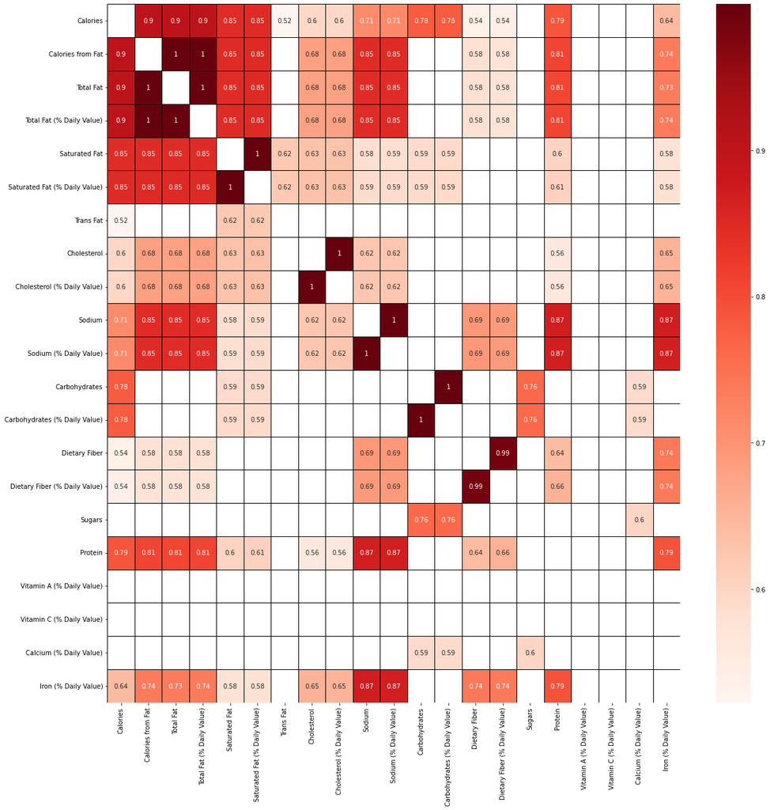

```python
plt.figure(figsize=(20,20))
sns.heatmap(filteredDf, annot=True, cmap="Reds", linewidths=1, linecolor='black')
plt.show()
```

**Linear relationship between the variables are shown below in the regplots: which shows very high linearity between the variables.**

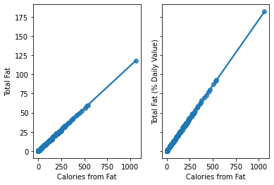

```python
fig, (ax1, ax2) = plt.subplots(ncols=2, sharey=True)
sns.regplot('Calories from Fat','Total Fat', data=df, ax=ax1);
sns.regplot('Calories from Fat','Total Fat (% Daily Value)', data=df, ax=ax2);
```

**Linear relationship between the variables are shown below in the regplots: which shows that the linear relationship between these variables is weaker than the linear relationship shown in above regplots.**

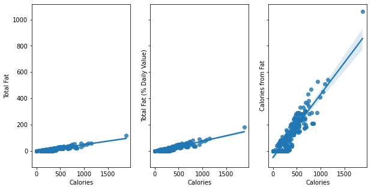

```python
fig, (ax1, ax2, ax3) = plt.subplots(ncols=3, sharey=True, figsize=(10,5))
sns.regplot('Calories','Total Fat', data=df, ax=ax1);
sns.regplot('Calories','Total Fat (% Daily Value)', data=df, ax=ax2);
sns.regplot('Calories','Calories from Fat', data=df, ax=ax3);
```

## 4. Which category contributes to the maximum % of Cholesterol in a diet (% daily value)?

```python
df['Cholesterol (% Daily Value)'].max()
```

```
192
```

```python
df[df['Cholesterol (% Daily Value)']==192].T
```

|  | 31 | 32 |
| --- | --- | --- |
| Category | Breakfast | Breakfast |
| Item | Big Breakfast with Hotcakes (Regular Biscuit) | Big Breakfast with Hotcakes (Large Biscuit) |
| Serving Size | 14.8 oz (420 g) | 15.3 oz (434 g) |
| Calories | 1090 | 1150 |
| Calories from Fat | 510 | 540 |
| Total Fat | 56.0 | 60.0 |
| Total Fat (% Daily Value) | 87 | 93 |
| Saturated Fat | 19.0 | 20.0 |
| Saturated Fat (% Daily Value) | 96 | 100 |
| Trans Fat | 0.0 | 0.0 |
| Cholesterol | 575 | 575 |
| Cholesterol (% Daily Value) | 192 | 192 |
| Sodium | 2150 | 2260 |
| Sodium (% Daily Value) | 90 | 94 |
| Carbohydrates | 111 | 116 |
| Carbohydrates (% Daily Value) | 37 | 39 |
| Dietary Fiber | 6 | 7 |
| Dietary Fiber (% Daily Value) | 23 | 28 |
| Sugars | 17 | 17 |
| Protein | 36 | 36 |
| Vitamin A (% Daily Value) | 15 | 15 |
| Vitamin C (% Daily Value) | 2 | 2 |
| Calcium (% Daily Value) | 25 | 30 |
| Iron (% Daily Value) | 40 | 40 |

_**1) One way to show in the plot:**_

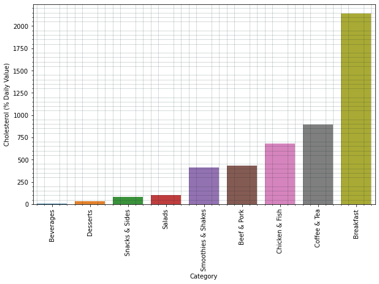

```python
sns.barplot(x=df.groupby(by='Category').agg('Cholesterol (% Daily Value)').sum().sort_values().keys(),
            y=df.groupby(by='Category').agg('Cholesterol (% Daily Value)').sum().sort_values());
plt.xticks(rotation = 90); # This code display the country names on x-axis verticaly
fig = plt.gcf()
fig.set_figwidth(10)
fig.set_figheight(6)
plt.minorticks_on()
plt.grid(b=True, which='minor', color='#011f1f', linestyle='-', alpha=0.2)
```

_**Observation**_: **"Breakfast" Category contains the highest % of Cholestrol and "Beverages" Category contains the least % of Cholestrol.**

_**2) Another way:**_

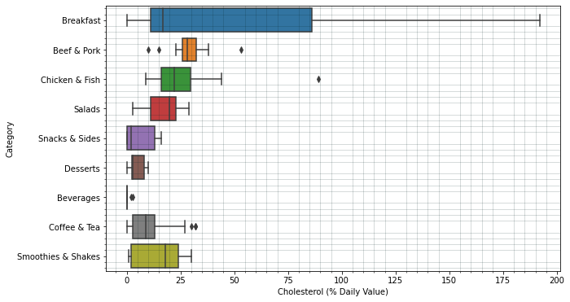

```python
sns.boxplot('Cholesterol (% Daily Value)','Category',data=df);
fig = plt.gcf()
fig.set_figwidth(10)
fig.set_figheight(6)
plt.minorticks_on()
plt.grid(b=True, which='minor', color='#011f1f', linestyle='-', alpha=0.2)
```

_**3) Third way to show which Item contributes to the maximum % of Cholestrol:**_

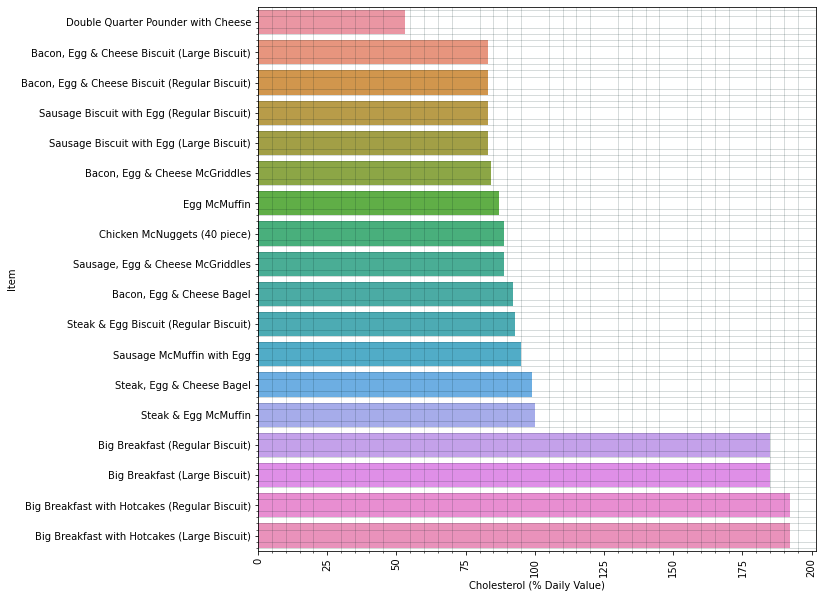

```python
chunk2=df[df['Cholesterol (% Daily Value)']>50]
sns.barplot(x=chunk2.groupby(by='Item').agg('Cholesterol (% Daily Value)').sum().sort_values(),
            y=chunk2.groupby(by='Item').agg('Cholesterol (% Daily Value)').sum().sort_values().keys());
plt.xticks(rotation = 90); # This code display the country names on x-axis verticaly
fig = plt.gcf()
fig.set_figwidth(10)
fig.set_figheight(10)
plt.minorticks_on()
plt.grid(b=True, which='minor', color='#011f1f', linestyle='-', alpha=0.2)
```

## 5. Which item contributes maximum to the Sodium intake?

```python
df['Sodium'].max()
```

```
3600
```

```python
df[df["Sodium"]==3600].T

#chicken McNuggets(40pieces) has the highest value of Sodium, is, 3600.
```

|  | 82 |
| --- | --- |
| Category | Chicken & Fish |
| Item | Chicken McNuggets (40 piece) |
| Serving Size | 22.8 oz (646 g) |
| Calories | 1880 |
| Calories from Fat | 1060 |
| Total Fat | 118.0 |
| Total Fat (% Daily Value) | 182 |
| Saturated Fat | 20.0 |
| Saturated Fat (% Daily Value) | 101 |
| Trans Fat | 1.0 |
| Cholesterol | 265 |
| Cholesterol (% Daily Value) | 89 |
| Sodium | 3600 |
| Sodium (% Daily Value) | 150 |
| Carbohydrates | 118 |
| Carbohydrates (% Daily Value) | 39 |
| Dietary Fiber | 6 |
| Dietary Fiber (% Daily Value) | 24 |
| Sugars | 1 |
| Protein | 87 |
| Vitamin A (% Daily Value) | 0 |
| Vitamin C (% Daily Value) | 15 |
| Calcium (% Daily Value) | 8 |
| Iron (% Daily Value) | 25 |

_**Now Looking at each food item present in "Chicken & Fish" Category and their "Sodium" intake:**_

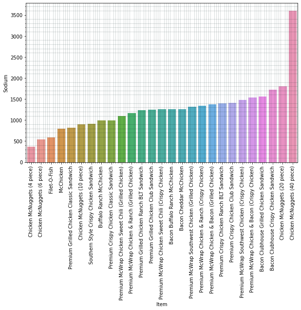

```python
chunk=df[df["Category"]=="Chicken & Fish"]
sns.barplot(x=chunk.groupby(by='Item').agg('Sodium').sum().sort_values().keys(),
            y=chunk.groupby(by='Item').agg('Sodium').sum().sort_values());
plt.xticks(rotation = 90); # This code display the country names on x-axis verticaly
fig = plt.gcf()
fig.set_figwidth(10)
fig.set_figheight(6)
plt.minorticks_on()
plt.grid(b=True, which='minor', color='#011f1f', linestyle='-', alpha=0.2)
```

_**Observation**_: **In "chicken & Fish" Category: Chicken McNuggets(4 piece) contributes towards lowest Sodium Intake which is around 400. Chicken McNuggets(40 piece) contributes towards highest Sodium Intake which is 3600.**

_**Another way to show which Item contributes to the maximum Sodium Intake:**_

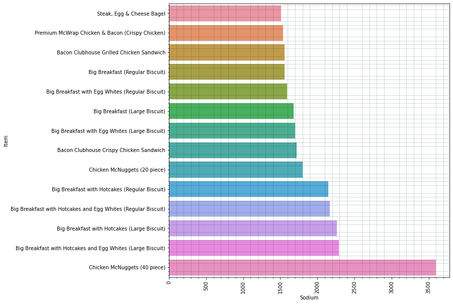

```python
chunk3=df[df['Sodium']>1500]
sns.barplot(x=chunk3.groupby(by='Item').agg('Sodium').sum().sort_values(),
            y=chunk3.groupby(by='Item').agg('Sodium').sum().sort_values().keys());
plt.xticks(rotation = 90); # This code display the country names on x-axis verticaly
fig = plt.gcf()
fig.set_figwidth(10)
fig.set_figheight(10)
plt.minorticks_on()
plt.grid(b=True, which='minor', color='#011f1f', linestyle='-', alpha=0.2)
```

## 6. Which 4 food items contain the most amount of Saturated Fat?

```python
df["Saturated Fat"].max()    #to check the maximum value
```

```
20.0
```

```python
df[df["Saturated Fat"]>17].head()          #just to look at the table
```

|  | Category | Item | Serving Size | Calories | Calories from Fat | Total Fat | Total Fat (% Daily Value) | Saturated Fat | Saturated Fat (% Daily Value) | Trans Fat | ... | Carbohydrates | Carbohydrates (% Daily Value) | Dietary Fiber | Dietary Fiber (% Daily Value) | Sugars | Protein | Vitamin A (% Daily Value) | Vitamin C (% Daily Value) | Calcium (% Daily Value) | Iron (% Daily Value) |
| --- | --- | --- | --- | --- | --- | --- | --- | --- | --- | --- | --- | --- | --- | --- | --- | --- | --- | --- | --- | --- | --- |
| 28 | Breakfast | Big Breakfast (Large Biscuit) | 10 oz (283 g) | 800 | 470 | 52.0 | 80 | 18.0 | 90 | 0.0 | ... | 56 | 19 | 4 | 17 | 3 | 28 | 15 | 2 | 15 | 30 |
| 31 | Breakfast | Big Breakfast with Hotcakes (Regular Biscuit) | 14.8 oz (420 g) | 1090 | 510 | 56.0 | 87 | 19.0 | 96 | 0.0 | ... | 111 | 37 | 6 | 23 | 17 | 36 | 15 | 2 | 25 | 40 |
| 32 | Breakfast | Big Breakfast with Hotcakes (Large Biscuit) | 15.3 oz (434 g) | 1150 | 540 | 60.0 | 93 | 20.0 | 100 | 0.0 | ... | 116 | 39 | 7 | 28 | 17 | 36 | 15 | 2 | 30 | 40 |
| 47 | Beef & Pork | Double Quarter Pounder with Cheese | 10 oz (283 g) | 750 | 380 | 43.0 | 66 | 19.0 | 96 | 2.5 | ... | 42 | 14 | 3 | 11 | 10 | 48 | 10 | 2 | 30 | 35 |
| 82 | Chicken & Fish | Chicken McNuggets (40 piece) | 22.8 oz (646 g) | 1880 | 1060 | 118.0 | 182 | 20.0 | 101 | 1.0 | ... | 118 | 39 | 6 | 24 | 1 | 87 | 0 | 15 | 8 | 25 |

5 rows × 24 columns

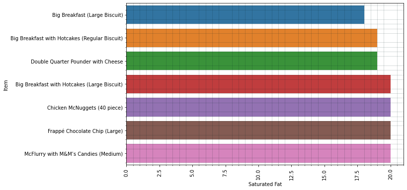

```python
chunk1=df[df["Saturated Fat"]>17]
sns.barplot(x=chunk1.groupby(by='Item').agg('Saturated Fat').sum().sort_values(),
            y=chunk1.groupby(by='Item').agg('Saturated Fat').sum().sort_values().keys());
plt.xticks(rotation = 90); # This code display the country names on x-axis verticaly
fig = plt.gcf()
fig.set_figwidth(10)
fig.set_figheight(6)
plt.minorticks_on()
plt.grid(b=True, which='minor', color='#011f1f', linestyle='-', alpha=0.2)
```

_**Four Items with Highest Value of Saturated Fat:**_

1. Big Breakfast with Hotcakes (Large Biscuit)
2. Chicken McNuggets (40 piece),
3. Frappe Chocolate Chip(Large),
4. McFlurry with M&M's Candies (Medium).**

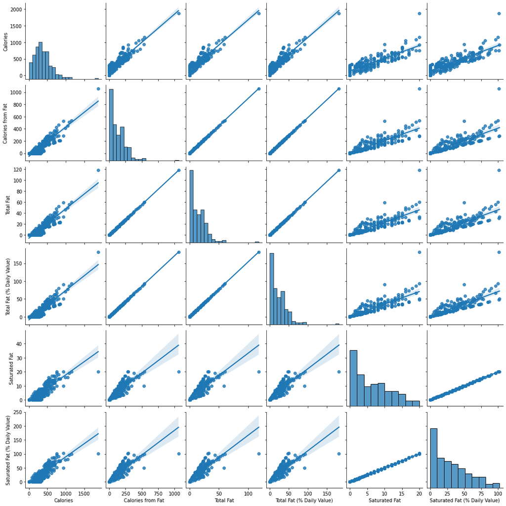

```python
sns.pairplot(data=df, vars=['Calories','Calories from Fat',
                            'Total Fat','Total Fat (% Daily Value)',
                            'Saturated Fat',
                            'Saturated Fat (% Daily Value)'], kind='reg' );
```

_**Observation**_:

**From the above plot, it can be seen that there is a linear relationship between the variables:**

1. 'Calories'
2. 'Calories from Fat',
3. 'Total Fat'
4. 'Total Fat (% Daily Value)',
5. 'Saturated Fat',
6. 'Saturated Fat (% Daily Value)'

**From above observation, it can be concluded that those Items that have a high value of 'Calories from Fat' will have a high value of 'Calories', 'Total Fat', 'Total Fat (% Daily Value)', 'Saturated Fat' and 'Saturated Fat (% Daily Value)'.**

**For the same reason, Same items can be marked as Unhealthy foods.**

```python
df["Calories from Fat"].max()    #to check the maximum value
```

```
1060
```

```python
df[df["Calories from Fat"]>300].head()          #just to look at the table
```

|  | Category | Item | Serving Size | Calories | Calories from Fat | Total Fat | Total Fat (% Daily Value) | Saturated Fat | Saturated Fat (% Daily Value) | Trans Fat | ... | Carbohydrates | Carbohydrates (% Daily Value) | Dietary Fiber | Dietary Fiber (% Daily Value) | Sugars | Protein | Vitamin A (% Daily Value) | Vitamin C (% Daily Value) | Calcium (% Daily Value) | Iron (% Daily Value) |
| --- | --- | --- | --- | --- | --- | --- | --- | --- | --- | --- | --- | --- | --- | --- | --- | --- | --- | --- | --- | --- | --- |
| 13 | Breakfast | Sausage Biscuit with Egg (Large Biscuit) | 6.2 oz (177 g) | 570 | 330 | 37.0 | 57 | 15.0 | 74 | 0.0 | ... | 42 | 14 | 3 | 11 | 3 | 18 | 10 | 0 | 10 | 20 |
| 26 | Breakfast | Steak, Egg & Cheese Bagel | 8.5 oz (241 g) | 670 | 310 | 35.0 | 53 | 13.0 | 63 | 1.5 | ... | 56 | 19 | 3 | 12 | 7 | 33 | 20 | 4 | 25 | 25 |
| 27 | Breakfast | Big Breakfast (Regular Biscuit) | 9.5 oz (269 g) | 740 | 430 | 48.0 | 73 | 17.0 | 87 | 0.0 | ... | 51 | 17 | 3 | 12 | 3 | 28 | 15 | 2 | 15 | 25 |
| 28 | Breakfast | Big Breakfast (Large Biscuit) | 10 oz (283 g) | 800 | 470 | 52.0 | 80 | 18.0 | 90 | 0.0 | ... | 56 | 19 | 4 | 17 | 3 | 28 | 15 | 2 | 15 | 30 |
| 29 | Breakfast | Big Breakfast with Egg Whites (Regular Biscuit) | 9.6 oz (272 g) | 640 | 330 | 37.0 | 57 | 14.0 | 69 | 0.0 | ... | 50 | 17 | 3 | 12 | 3 | 26 | 0 | 2 | 10 | 15 |

5 rows × 24 columns

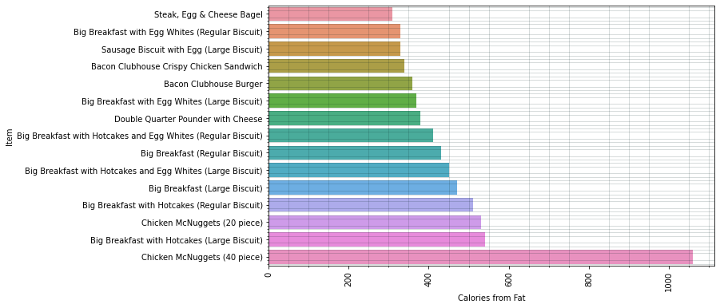

```python
chunk4=df[df["Calories from Fat"]>300]
sns.barplot(x=chunk4.groupby(by='Item').agg('Calories from Fat').sum().sort_values(),
            y=chunk4.groupby(by='Item').agg('Calories from Fat').sum().sort_values().keys());
plt.xticks(rotation = 90); # This code display the country names on x-axis verticaly
fig = plt.gcf()
fig.set_figwidth(10)
fig.set_figheight(6)
plt.minorticks_on()
plt.grid(b=True, which='minor', color='#011f1f', linestyle='-', alpha=0.2)
```

**From above plot, it can be seen that some of the unhealthy foods are:**

1. Big Breakfast with Hotcakes and Egg Whites(Large Biscuit)
2. Big Breakfast (Large Biscuit)
3. Big Breakfast with Hotcakes (Regular Biscuit)
4. Chicken McNuggets (20 piece)
5. Big Breakfast with Hotcakes (Large Biscuit)
6. Chicken McNuggets (40 Piece)